# Lecture Notes: Simple Linear Regression

POSC 8410 — board derivations and You Try answers

Author

Will Horne

Published

November 10, 2026

# Board derivations

## 1. The slope, filled in

*Slide: Now the Slope. The slide says “differentiate, set to zero, and substitute”; these are the steps.*

Differentiate the sum of squared residuals with respect to $\beta_1$ and set it to zero:

$$\frac{\partial}{\partial \beta_1}\sum_i (y_i - \beta_0 - \beta_1 x_i)^2 = -2\sum_i x_i\,(y_i - \beta_0 - \beta_1 x_i) = 0$$

Substitute the intercept condition $\beta_0 = \bar{y} - \beta_1\bar{x}$ from the previous slide. The term in parentheses becomes $(y_i - \bar{y}) - \beta_1(x_i - \bar{x})$, so

$$\sum_i x_i\,(y_i - \bar{y}) = \beta_1 \sum_i x_i\,(x_i - \bar{x})$$

This is already the answer, in a less recognizable form. One step converts it. Deviations from a mean sum to zero, so $\sum_i \bar{x}\,(y_i - \bar{y}) = \bar{x}\sum_i (y_i - \bar{y}) = 0$. Subtracting that zero from the left side, and the matching zero from the right, replaces each $x_i$ with $x_i - \bar{x}$:

$$\hat{\beta}_1 = \frac{\sum_i (x_i - \bar{x})(y_i - \bar{y})}{\sum_i (x_i - \bar{x})^2}$$

Two points worth drawing out:

- **The divisor cancels.** Dividing top and bottom by $n - 1$ turns them into the sample covariance and sample variance, so the ratio is the same whichever divisor you use. That is why `cov()/var()` matches `lm` exactly on the Check It slide.
- **The slope needs variation in** $X$. If every $x_i$ is the same, the denominator is zero and the slope is undefined. You cannot learn how $Y$ changes with $X$ from data in which $X$ never changes. Multiple regression extends this: a predictor that is a perfect linear function of the others gets dropped (R reports `NA`).

## 2. The two derivatives are the two guarantees

*Slide: What Least Squares Guarantees.*

The two first-order conditions, written in terms of the residuals $e_i = y_i - \hat{\beta}_0 - \hat{\beta}_1 x_i$, are

$$\sum_i e_i = 0 \qquad \text{and} \qquad \sum_i x_i\, e_i = 0$$

These are the slide’s two results. They are not consequences of the derivation; they *are* the derivation. Least squares is defined by those two equations, which is why the residuals satisfy them exactly in every dataset. Since each fitted value is a linear function of $x_i$, the residuals are also uncorrelated with the fitted values: $\sum_i \hat{y}_i e_i = 0$. Derivation 4 needs that.

**Why this is not a diagnostic.** The unlogged model is misspecified, since the CEF clearly curves. Its residuals satisfy both conditions anyway:

```r
round(c(sum_resid       = sum(resid(m0)),
        cor_with_gdp    = cor(resid(m0), g07$gdpPercap),  # zero by construction
        cor_with_loggdp = cor(resid(m0), g07$lgdp)), 3)   # the missed curve
```

```
      sum_resid    cor_with_gdp cor_with_loggdp
          0.000           0.000           0.293
```

The residuals have no *linear* relationship with the variable in the model, by construction. They are clearly related to a transformation of it. Least squares removes only the straight-line part of the relationship, so a residual plot looks for curves, fans and clusters, not for correlation with $X$.

## 3. The unbiasedness algebra the slide skips

*Slides: Is It Unbiased?, Taking Expectations.*

The slide moves from $\sum_i d_i y_i / \sum_i d_i^2$ to “truth plus weighted errors” in one line. Two facts about the deviations $d_i = x_i - \bar{x}$ make it work:

$$\sum_i d_i = 0 \qquad \text{and} \qquad \sum_i d_i\, x_i = \sum_i d_i\,(x_i - \bar{x}) + \bar{x}\sum_i d_i = \sum_i d_i^2$$

The first line also explains the numerator on the slide: $\sum_i d_i (y_i - \bar{y}) = \sum_i d_i y_i - \bar{y}\sum_i d_i = \sum_i d_i y_i$. Now substitute the true model:

$$\sum_i d_i\, y_i = \beta_0 \underbrace{\sum_i d_i}_{0} + \beta_1 \underbrace{\sum_i d_i x_i}_{\sum d_i^2} + \sum_i d_i\,\varepsilon_i$$

Divide by $\sum_i d_i^2$ and you have the slide. The intercept drops out entirely. The slope does not depend on where the line sits, only on how it tilts.

**On “treat the** $x_i$ as fixed.” In observational data $X$ is random too. The argument goes through if $E[\varepsilon_i \mid X] = 0$: condition on the $x$’s, run the slide’s argument, then average over them with the law of iterated expectations from the conditional expectation session. This is a stronger requirement than $E[\varepsilon_i] = 0$. It says that knowing a country’s income tells you nothing about its error. It fails whenever something omitted from the model, such as disease burden or quality of governance, moves with income and also affects life expectancy.

**A preview of next class.** The same expression gives the variance. If the errors are independent with common variance $\sigma^2$, then

$$\text{Var}(\hat{\beta}_1) = \frac{\sum_i d_i^2\,\text{Var}(\varepsilon_i)}{\big(\sum_i d_i^2\big)^2} = \frac{\sigma^2}{\sum_i d_i^2}$$

Plug in the residual standard error for $\sigma$:

```r
sigma(m1) / sqrt(sum(d^2))                                 # by hand
```

```
[1] 0.4423393
```

```r
summary(m1)$coefficients["lgdp", "Std. Error"]            # lm's standard error
```

```
[1] 0.4423393
```

That is where the standard error in the output comes from. The formula shows what makes a slope precise: little noise around the line (small $\sigma$), many observations, and a wide spread in $X$ (both raise $\sum d_i^2$). It also shows which assumptions it leans on, constant variance and independence, which is next class’s subject.

## 4. Where $R^2$ comes from

*Slide:* $R^2$.

Write each deviation from the mean as the part the line explains plus the residual: $y_i - \bar{y} = (\hat{y}_i - \bar{y}) + e_i$. Square and sum:

$$\underbrace{\sum_i (y_i - \bar{y})^2}_{\text{total}} = \underbrace{\sum_i (\hat{y}_i - \bar{y})^2}_{\text{explained}} + \underbrace{\sum_i e_i^2}_{\text{residual}} + 2\underbrace{\sum_i (\hat{y}_i - \bar{y})\,e_i}_{0}$$

The cross term is zero by derivation 2: residuals sum to zero and are uncorrelated with the fitted values. So the variation splits cleanly, and

$$R^2 = 1 - \frac{\sum_i e_i^2}{\sum_i (y_i - \bar{y})^2}$$

is the proportional reduction in squared error from using the line instead of $\bar{y}$. The clean split is a least squares property. For other fitting methods, the pieces do not add up.

In simple regression only, $R^2$ is the squared correlation:

```r
c(R2 = summary(m1)$r.squared, cor_squared = cor(g07$lgdp, g07$lifeExp)^2)
```

```
         R2 cor_squared
   0.654449    0.654449
```

So $R^2$ is symmetric. Regressing log GDP on life expectancy gives the same $R^2$, although a different slope. It measures how tightly the points hug a line, not which way any effect runs.

## 5. Why the residual standard error divides by $n - 2$

*Slide: Residual Standard Error.*

```r
sqrt(sum(resid(m1)^2) / (n - 2))   # by hand
```

```
[1] 7.122255
```

```r
sigma(m1)                          # R's value
```

```
[1] 7.122255
```

The argument parallels the $n - 1$ proof from the estimators session. Residuals are measured from a line fitted to the same data, so they run smaller than the true errors. The two conditions in derivation 2 bind the residuals: once you know $n - 2$ of them, the other two are determined. Dividing by $n - 2$ corrects for the two estimated parameters, just as $n - 1$ corrected for estimating the mean. With $n =$ 142, the correction is tiny. With $k$ predictors and an intercept it becomes $n - k - 1$.

## 6. Reading log coefficients exactly

*Slides: Four Ways to Write a Regression, Our Data, Reading the Log-Log.*

The table on the slide uses approximations. Here is where each comes from, and when it breaks.

**Linear–log.** A 1% rise in $X$ raises $\log X$ by $\log(1.01) \approx 0.01$, so $Y$ rises by about $\beta_1/100$. With our slope that is 0.072 years. That number is hard to feel. A better translation for this model is **doubling**: doubling GDP per capita raises $\log X$ by $\log 2 \approx 0.69$, so predicted life expectancy rises by $\beta_1 \log 2 =$ 5.0 years. This is the same at every income level, and that constant return to each doubling is the “diminishing returns” the log builds in. Going from $1,000 to $2,000 buys as much as going from $20,000 to $40,000.

**Log–linear.** A one-unit rise in $X$ multiplies $Y$ by $e^{\beta_1}$, an exact change of $100(e^{\beta_1} - 1)$ percent. The slide’s $100\beta_1$ is the first-order approximation, using $e^{b} \approx 1 + b$ for small $b$.

```r
g2 <- g07 |> mutate(lly = log(lifeExp))
b_ll <- coef(lm(lly ~ gdpPercap, data = g2))[2]

# Effect of an extra $1,000, which is easier to read than an extra $1
c(approx_pct = 100 * b_ll * 1000, exact_pct = 100 * (exp(b_ll * 1000) - 1))
```

```
approx_pct.gdpPercap  exact_pct.gdpPercap
           0.9790682            0.9838767
```

```r
# The approximation degrades as the coefficient grows
tibble(beta = c(0.01, 0.05, 0.10, 0.25, 0.50)) |>
  mutate(approx_pct = 100 * beta, exact_pct = 100 * (exp(beta) - 1)) |>
  knitr::kable(digits = 1)
```

| beta | approx_pct | exact_pct |
| --- | --- | --- |
| 0.0 | 1 | 1.0 |
| 0.0 | 5 | 5.1 |
| 0.1 | 10 | 10.5 |
| 0.2 | 25 | 28.4 |
| 0.5 | 50 | 64.9 |

The rule of thumb is fine below about 0.10. Above that, report the exact figure. This often matters with dummy variables in log-outcome models, where coefficients of 0.3 or 0.5 are common.

**Log–log.** Differentiate $\log Y = \beta_0 + \beta_1 \log X$: $\beta_1 = \frac{d \log Y}{d \log X} = \frac{dY/Y}{dX/X}$, a ratio of proportional changes. That is the definition of an elasticity, and why it is unit-free.

**A caution on comparing fit across these models.** $R^2$ can be compared between the first two rows, because they share the outcome. It cannot be compared between models with $Y$ and $\log Y$ as outcomes, because they explain variation in different quantities.

## 7. Centering, and what the new intercept means

*Slide: Intercepts Are Often Nonsense.*

Let $\tilde{x}_i = x_i - \bar{x}$. Its mean is zero, so the intercept formula gives $\hat{\beta}_0 = \bar{y} - \hat{\beta}_1 \cdot 0 = \bar{y}$. The slope does not change, because covariance and variance are unaffected by shifting a variable. Shifting $X$ slides the line’s origin without tilting it.

One subtlety is worth raising in class. In this model the centered intercept, 67.0 years, is the predicted life expectancy at the mean of **log** GDP. The mean of a log is the log of the geometric mean, so that is a country at

```r
c(geometric_mean = exp(xbar), arithmetic_mean = mean(g07$gdpPercap))
```

```
 geometric_mean arithmetic_mean
       5518.095       11680.072
```

$5,518, not $11,680. Income is right-skewed, so the arithmetic mean is pulled up by a few rich countries. When you center a logged variable, say “at the typical (geometric mean) income,” not “at average income.”

## 8. The confidence and prediction interval formulas

*Slides: Two Different Predictions, Why So Different?*

The fitted value at $x_0$ is $\hat{y}_0 = \hat{\beta}_0 + \hat{\beta}_1 x_0 = \bar{y} + \hat{\beta}_1 (x_0 - \bar{x})$. Under the assumptions of derivation 3, $\bar{y}$ and $\hat{\beta}_1$ are uncorrelated, so

$$\text{Var}(\hat{y}_0) = \sigma^2\left[\frac{1}{n} + \frac{(x_0 - \bar{x})^2}{\sum_i d_i^2}\right]$$

That is the uncertainty in the line’s height, from the intercept, and in its tilt, from the slope. A new country’s outcome is $y_0 = \beta_0 + \beta_1 x_0 + \varepsilon_0$, so predicting it adds a fresh error that is independent of the fitted line:

$$\text{Var}(y_0 - \hat{y}_0) = \sigma^2\left[1 + \frac{1}{n} + \frac{(x_0 - \bar{x})^2}{\sum_i d_i^2}\right]$$

That “1 +” is the slide’s $\sigma_\varepsilon^2$. The other two terms shrink like $1/n$; the 1 does not.

```r
x0 <- log(10000)
lever <- 1 / n + (x0 - xbar)^2 / sum(d^2)
yhat  <- unname(predict(m1, tibble(lgdp = x0)))
tcrit <- qt(0.975, df = n - 2)

rbind(confidence = yhat + c(-1, 1) * tcrit * sigma(m1) * sqrt(lever),
      prediction = yhat + c(-1, 1) * tcrit * sigma(m1) * sqrt(1 + lever))
```

```
               [,1]     [,2]
confidence 69.99887 72.58086
prediction 57.14973 85.43000
```

These match `predict()` on the slide. The ratio of widths is $\sqrt{(1 + \text{lever})/\text{lever}} =$ 11.0, the slide’s “more than ten times.”

**The bands bow outward.** The $(x_0 - \bar{x})^2$ term makes both intervals widest far from the mean of $X$. A small error in the slope matters more the further you get from the center of the data:

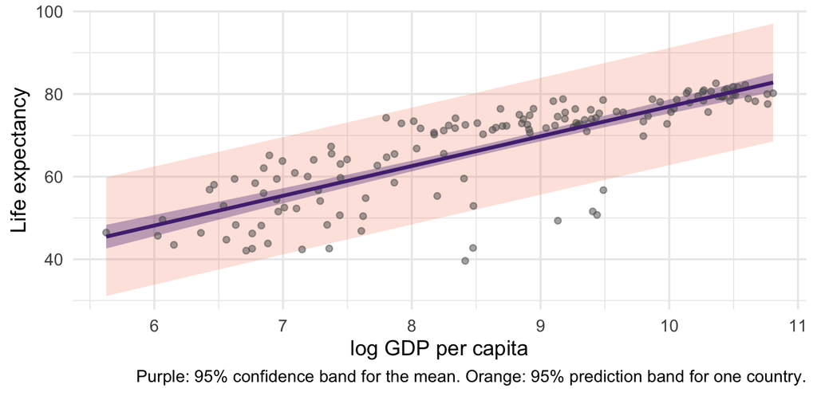

```r
grid <- tibble(lgdp = seq(min(g07$lgdp), max(g07$lgdp), length.out = 200))
conf_b <- as_tibble(predict(m1, grid, interval = "confidence"))
pred_b <- as_tibble(predict(m1, grid, interval = "prediction"))
bands  <- bind_cols(grid,
                    rename_with(conf_b, ~ paste0("c_", .x)),
                    rename_with(pred_b, ~ paste0("p_", .x)))

ggplot(bands, aes(lgdp)) +
  geom_ribbon(aes(ymin = p_lwr, ymax = p_upr), fill = "#F66733", alpha = .18) +
  geom_ribbon(aes(ymin = c_lwr, ymax = c_upr), fill = "#522D80", alpha = .35) +
  geom_point(data = g07, aes(y = lifeExp),
             alpha = .5, color = "grey35", size = 1.5) +
  geom_line(aes(y = c_fit), color = "#522D80", linewidth = 1.1) +
  labs(x = "log GDP per capita", y = "Life expectancy",
       caption = paste("Purple: 95% confidence band for the mean.",
                       "Orange: 95% prediction band for one country.")) +
  theme_minimal(base_size = 13)
```

At the extremes, the confidence band visibly widens. The prediction band barely changes, because the constant $\sigma^2$ dominates it everywhere. Beyond the observed range of $X$, neither band accounts for the real risk, which is that the line itself is the wrong shape out there. That is the extrapolation problem from the intercept slide.

# You Try answers

The student-facing version, with fuller explanations, is in `21_Simple_Regression_YouTry_Answers.qmd`.

**1. Regress `lifeExp` on unlogged `gdpPercap`. Compare** $R^2$ to the logged version.

```r
c(unlogged = summary(m0)$r.squared, logged = summary(m1)$r.squared)
```

```
 unlogged    logged
0.4605827 0.6544490
```

The logged model fits better, 0.65 against 0.46. The CEF is concave: an extra dollar matters a great deal in a poor country and very little in a rich one. A straight line in dollars overpredicts at the top and underpredicts in the middle. The comparison is valid because both models have the same outcome (derivation 6).

**2. Slope by hand.** `cov(lgdp, lifeExp) / var(lgdp)` gives 7.2028, identical to `lm`. Watch for students who use unlogged `gdpPercap` in one and `lgdp` in the other.

**3. The line passes through** $(\bar{x}, \bar{y})$. `predict(m1, tibble(lgdp = mean(g07$lgdp)))` returns 67.0074, and `mean(g07$lifeExp)` is 67.0074.

**4. Center `lgdp` and refit.**

```r
g07c <- g07 |> mutate(lgdp_c = lgdp - mean(lgdp))
m1c  <- lm(lifeExp ~ lgdp_c, data = g07c)
rbind(original = coef(m1), centered = coef(m1c))
```

```
         (Intercept)     lgdp
original    4.949612 7.202802
centered   67.007423 7.202802
```

The intercept changed, to $\bar{y}$; the slope did not. $R^2$, $\hat{\sigma}$, the residuals and the fitted values are all unchanged too. Centering changes what the intercept *means*, not what the model *says*. Derivation 7’s geometric-mean point is a good follow-up question for the class.